# Mod1_IrisDataSet

```python
# must use pip install for mglearn
# Import all modules needed
import sys
import pandas as pd
import matplotlib
import numpy as np
import scipy as sp
import IPython
import sklearn
import mglearn
```

```python
# print versions being used
print("Python version: {}".format(sys.version))
print("pandas version: {}".format(pd.__version__))
print("matplotlib version: {}".format(matplotlib.__version__))
print("NumPy version: {}".format(np.__version__))
print("SciPy version: {}".format(sp.__version__))
print("IPython version: {}".format(IPython.__version__))
print("scikit-learn version: {}".format(sklearn.__version__))
```

```
Python version: 3.11.7 (main, Dec 15 2023, 12:09:56) [Clang 14.0.6 ]
pandas version: 2.2.2
matplotlib version: 3.8.0
NumPy version: 1.26.4
SciPy version: 1.11.4
IPython version: 8.20.0
scikit-learn version: 1.2.2
```

```python
# load iris dataset from scikit_learn
from sklearn.datasets import load_iris
iris_dataset = load_iris()
```

```python
# the iris object loaded is a Bunch object, similar to a dictionary containing Key:Value pairs
print("Keys of iris_dataset: \n{}".format(iris_dataset.keys()))
```

```
Keys of iris_dataset:
dict_keys(['data', 'target', 'frame', 'target_names', 'DESCR', 'feature_names', 'filename', 'data_module'])
```

```python
# A string that contains detailed text description of the dataset
# ['what you want to see'][:slicing to the number of characters]
# the elipsis ... means that there is more to read after
print(iris_dataset['DESCR'][:440]+"\n...")
```

```
.. _iris_dataset:

Iris plants dataset
--------------------

**Data Set Characteristics:**

    :Number of Instances: 150 (50 in each of three classes)
    :Number of Attributes: 4 numeric, predictive attributes and the class
    :Attribute Information:
        - sepal length in cm
        - sepal width in cm
        - petal length in cm
        - petal width in cm
        - class:
                - Iris-Setosa
                - Iris-Ve
...
```

```python
# A NumPy 'array' that contains the names of the target classes
print("Target names: {}".format(iris_dataset['target_names']))
```

```
Target names: ['setosa' 'versicolor' 'virginica']
```

```python
# '{}' is the place holder for the .format() method where (datset[list])
print("Feature names: \n{}".format(iris_dataset['feature_names']))
```

```
Feature names:
['sepal length (cm)', 'sepal width (cm)', 'petal length (cm)', 'petal width (cm)']
```

```python
# print lines of the dataset .format(dataset['list'][slice:lines])
print("First five columns of data:\n{}".format(iris_dataset['data'][:5]))
```

```
First five columns of data:
[[5.1 3.5 1.4 0.2]
 [4.9 3.  1.4 0.2]
 [4.7 3.2 1.3 0.2]
 [4.6 3.1 1.5 0.2]
 [5.  3.6 1.4 0.2]]
```

```python
# using the Iris.csv file to look at the data
iris_df = pd.read_csv('/Users/andrewbadzioch/Desktop/IntroML_FA24/Module_1/Iris.csv')
print(iris_df.head())
```

```
   Id  SepalLengthCm  SepalWidthCm  PetalLengthCm  PetalWidthCm      Species
0   1            5.1           3.5            1.4           0.2  Iris-setosa
1   2            4.9           3.0            1.4           0.2  Iris-setosa
2   3            4.7           3.2            1.3           0.2  Iris-setosa
3   4            4.6           3.1            1.5           0.2  Iris-setosa
4   5            5.0           3.6            1.4           0.2  Iris-setosa
```

```python
print(iris_df.info())
```

```
<class 'pandas.core.frame.DataFrame'>
RangeIndex: 150 entries, 0 to 149
Data columns (total 6 columns):
 #   Column         Non-Null Count  Dtype
---  ------         --------------  -----
 0   Id             150 non-null    int64
 1   SepalLengthCm  150 non-null    float64
 2   SepalWidthCm   150 non-null    float64
 3   PetalLengthCm  150 non-null    float64
 4   PetalWidthCm   150 non-null    float64
 5   Species        150 non-null    object
dtypes: float64(4), int64(1), object(1)
memory usage: 7.2+ KB
None
```

```python
print(iris_df.describe())
```

```
               Id  SepalLengthCm  SepalWidthCm  PetalLengthCm  PetalWidthCm
count  150.000000     150.000000    150.000000     150.000000    150.000000
mean    75.500000       5.843333      3.054000       3.758667      1.198667
std     43.445368       0.828066      0.433594       1.764420      0.763161
min      1.000000       4.300000      2.000000       1.000000      0.100000
25%     38.250000       5.100000      2.800000       1.600000      0.300000
50%     75.500000       5.800000      3.000000       4.350000      1.300000
75%    112.750000       6.400000      3.300000       5.100000      1.800000
max    150.000000       7.900000      4.400000       6.900000      2.500000
```

```python
iris_df.isnull().sum()
```

```
Id               0
SepalLengthCm    0
SepalWidthCm     0
PetalLengthCm    0
PetalWidthCm     0
Species          0
dtype: int64
```

**To read a column or row**

- Single column use df['ColumnName'] or df.ColumnName
- Single row use df.iloc[index] for index based selection or df.loc[label] for label based selection

```python
row_one = iris_df.loc[0]
print(row_one)
```

```
Id                         1
SepalLengthCm            5.1
SepalWidthCm             3.5
PetalLengthCm            1.4
PetalWidthCm             0.2
Species          Iris-setosa
Name: 0, dtype: object
```

```python
# chaining .head() method to see the first few enteries of a column (make sure it is outside of the main)
sep_length = iris_df['SepalLengthCm'].head()
print(sep_length)
```

```
0    5.1
1    4.9
2    4.7
3    4.6
4    5.0
Name: SepalLengthCm, dtype: float64
```

### Training and Testing

**The data is broken into two parts, one to build the model**

- Training Data (Training Set) is usually about 70% - 80%

**The rest is used to assess how well the model works**

- Test Data (Test Set) (Hold-out Set) is usually about 20% - 30%

```python
# use the scikit-learn function train_test_split() to automatically shuffle the dataset and split the data into training and testing portions
# in scikit-learn, the data is typically denoted as a capital X, and the labels are denoted by a lowercase y (x is the input, y is the output)
# capital X is also used because the data is a 2D array (a matrix)
# lowercase y is used because the target is a 1D array (a vecctor)

from sklearn.model_selection import train_test_split
X_train, X_test, y_train, y_test = train_test_split(iris_dataset['data'], iris_dataset['target'], random_state=0)

# iris_dataset['data'] the feature matrix of the Iris dataset, where each rom represents an instance (or sample), and each column represents a feature (petal length, sepal width)
# iris_dataset['target'] the target array, where each element corresponds to the label ot class for each instance in the dataset
# X_train, X_test contain the features (inputs) for the set
# y_train, y_test contain the labels (outputs) for the set
```

```python
# showing that X_train and y_train contain 75% of the data as 150 * .75 = 112.5
print("X_train shape: {}".format(X_train.shape))
print("y_train shape: {}".format(y_train.shape))
```

```
X_train shape: (112, 4)
y_train shape: (112,)
```

```python
# X_test an dy_test contain 25%
print("X_test shape: {}".format(X_test.shape))
print("y_test shape: {}".format(y_test.shape))
```

```
X_test shape: (38, 4)
y_test shape: (38,)
```

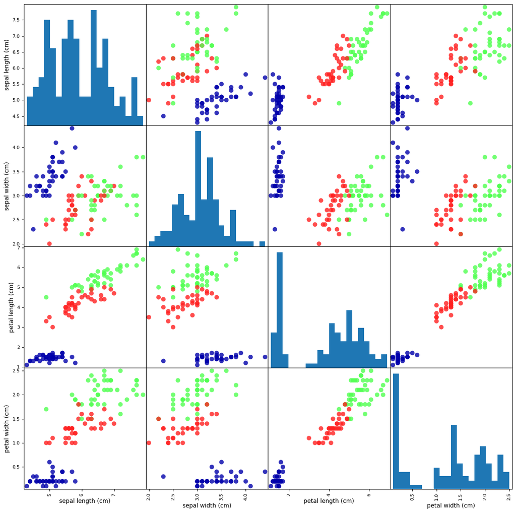

```python
# create dataframe from the data in X_train
# label the columns using the strings in iris_dataset.feature_names
iris_dataframe = pd.DataFrame(X_train, columns=iris_dataset.feature_names)
#create a scatter matrix from the dataframe, color by y_train
grr = pd.plotting.scatter_matrix(iris_dataframe, c=y_train, figsize=(15, 15), marker='o', hist_kwds={'bins': 20}, s=60, alpha=.8, cmap=mglearn.cm3)
```

## K-Nearest Neighbors (k-NN)

- The k in k-nearest neighbors allows any fixed number (k) of neighbors in the training (can be just about any number, but it is common to use odd numbers as even numbers can cause the algorithm to struggle when making decisions).
- Using 1 can make the model sensitive to noise, leading to overfitting, but a very large k can cause the model to be too generalized, leading to underfitting.
- Overfitting: occurs when a model learns not only the underlying patterns in the training data but also the noise and random fluctuations. This results in excellent performance on the training data but poor generalization to new, unseen data. Overfitting is like memorizing the training data rather than understanding the broader patterns.
- Underfitting: happens when a model is too simple to capture the underlying patterns in the data. It fails to perform well even on the training data and consequently also performs poorly on new data. Underfitting occurs when the model doesn’t learn enough from the data, often because it’s too basic or constrained.

### Building the Model

```python
# ML models in scikit-learn are impolemented in their own classes (Estimator classes)
# k-nearest neighbors in implemented in the KNeighborsClassifier, which must be instantiated (create an instance of something)
# the most important parameter is the number of neighbors (k) which be will to 1 here for practicing
from sklearn.neighbors import KNeighborsClassifier
knn = KNeighborsClassifier(n_neighbors=1)
```

```python
# When building the model, call the fit() method of the knn object
# X_train is the training data
# y_train is the corresponding training labels
knn.fit(X_train, y_train)
```

```
KNeighborsClassifier(n_neighbors=1)
```

## Making Predicions

```python
# Putting new data in using a NumPy array, calculating the shape (number of samples * number of features)
# data must be put into a 2D NumPy array (scikit-learn always expects 2D arrays)
X_new = np.array([[5, 2.9, 1, 0.2]])
print("X_new.shape: {}".format(X_new.shape))
```

```
X_new.shape: (1, 4)
```

```python
# making predictions on the new data with predict() method of the object
prediction = knn.predict(X_new)
print("Prediction: {}".format(prediction))
print("Predicted target name: {}".format(iris_dataset['target_names'][prediction]))
```

```
Prediction: [0]
Predicted target name: ['setosa']
```

### Evaluating the Model

```python
# Using the test set created earlier to measure how well the model works by computing the accuracy (the fraction of flowers for which the correct species was predicted)
y_pred = knn.predict(X_test)
print("Test set predictions:\n {}".format(y_pred))
```

```
Test set predictions:
 [2 1 0 2 0 2 0 1 1 1 2 1 1 1 1 0 1 1 0 0 2 1 0 0 2 0 0 1 1 0 2 1 0 2 2 1 0
 2]
```

```python
# Printing the test score (accuracy)
# using the mean() method
print("Test set score using mean: {:.2f}".format(np.mean(y_pred == y_test)))
# using the score() method of the knn object
print("Test set score using score: {:.2f}".format(knn.score(X_test, y_test)))
```

```
Test set score using mean: 0.97
Test set score using score: 0.97
```

### Cross validation of the dataset

```python
from sklearn.model_selection import cross_val_score
from sklearn.tree import DecisionTreeClassifier
```

```python
iris = load_iris()
X = iris.data
y = iris.target

decision_tree = DecisionTreeClassifier()
```

```python
dt_scores = cross_val_score(decision_tree, X, y, cv=5)
print("Decision Tree Cross_Validation Scores:", dt_scores)
print("Average Decision Tree Score:", dt_scores.mean())
```

```
Decision Tree Cross_Validation Scores: [0.96666667 0.96666667 0.9        0.96666667 1.        ]
Average Decision Tree Score: 0.9600000000000002
```

```python
knn_scores = cross_val_score(knn, X, y, cv=5)
print("k-NN Cross_Valisation Scores:", knn_scores)
print("Average k-NN Score:", knn_scores.mean())
```

```
k-NN Cross_Valisation Scores: [0.96666667 0.96666667 0.93333333 0.93333333 1.        ]
Average k-NN Score: 0.96
```